# cyclistic bike share V2

Antonio Nevarez

2025-09-04

# Business Task

Cyclistic wants to analyze bike-share usage patterns between **casual riders** and **annual members** to understand how to convert more casual users into members.

# Data Sources

- Divvy Trips Q1 2019 (CSV)
- Divvy Trips Q1 2020 (CSV)

Data was obtained directly from Divvy’s public datasets.

# Data Preparation & Cleaning

```r
# Load libraries
library(tidyverse)
library(dplyr)
library(janitor)
library(lubridate)
library(readr)
```

## Import datasets

```r
divvy2019_q1 <- read.csv("C:/Users/yisus/Downloads/Divvy_Trips_2019_Q1.csv")
divvy2020_q1 <- read.csv("C:/Users/yisus/Downloads/Divvy_Trips_2020_Q1.csv")
```

## Clean column names

```r
divvy2019_q1 <- clean_names(divvy2019_q1)
divvy2020_q1 <- clean_names(divvy2020_q1)
```

## Standardize column names

```r
divvy2019_q1 <- divvy2019_q1 %>%
  rename(
    started_at = start_time,
    ended_at = end_time,
    start_station_name = from_station_name,
    start_station_id = from_station_id,
    end_station_name = to_station_name,
    end_station_id = to_station_id

  )
divvy2020_q1 <- divvy2020_q1 %>%
  rename(usertype = member_casual)
```

## Combine datasets

```r
all_bike_trips <- bind_rows(divvy2019_q1, divvy2020_q1)
```

# Harmonize usertype labels

```r
all_bike_trips <- all_bike_trips %>%
  mutate(usertype = recode(usertype,
                           "Subscriber" = "member",
                           "Customer"   = "casual"))
```

## Convert datetime fields

```r
all_bike_trips <- all_bike_trips %>%
  mutate(
    started_at = ymd_hms(started_at),
    ended_at   = ymd_hms(ended_at)
  )
```

## Trip duration (minutes)

```r
all_bike_trips <- all_bike_trips %>%
  mutate(ride_length = as.numeric(difftime(ended_at, started_at, units = "mins")))
```

## Remove unwanted/invalid data

```r
all_bike_trips <- all_bike_trips %>%
  filter(ride_length >= 1 & ride_length <= 1440) %>%     # keep trips 1 min – 24 hr
  filter(!is.na(usertype)) %>%                          # remove missing usertypes
  distinct()                                            # remove duplicates
```

## Remove test rides

```r
all_bike_trips <- all_bike_trips %>%
  filter(!(start_station_name == "HQ QR" | ride_length < 0))
```

## Create new variables

```r
all_bike_trips <- all_bike_trips %>%
  mutate(
    day_of_week = weekdays(started_at),
    date        = as.Date(started_at),
    hour        = hour(started_at),
    month       = month(started_at, label = TRUE, abbr = TRUE),
    is_weekend  = day_of_week %in% c("Saturday", "Sunday")
  )
```

```r
usertype_summary <- all_bike_trips %>%
  group_by(usertype) %>%
  summarise(
    mean_length   = mean(ride_length, na.rm = TRUE),
    median_length = median(ride_length, na.rm = TRUE),
    max_length    = max(ride_length, na.rm = TRUE),
    min_length    = min(ride_length, na.rm = TRUE)
  )
usertype_summary
```

```
## # A tibble: 2 × 5
##   usertype mean_length median_length max_length min_length
##   <chr>          <dbl>         <dbl>      <dbl>      <dbl>
## 1 casual          38.5          23.2      1436.       1.02
## 2 member          11.5           8.5      1433.       1
```

# Analyze ridership by day of week

```r
all_bike_trips %>%
  mutate(weekday = wday(started_at, label = TRUE)) %>%
  group_by(usertype, weekday) %>%
  summarise(
    number_of_rides  = n(),
    average_duration = mean(ride_length, na.rm = TRUE)
  ) %>%
  arrange(usertype, weekday)
```

```
## # A tibble: 14 × 4
## # Groups:   usertype [2]
##    usertype weekday number_of_rides average_duration
##    <chr>    <ord>             <int>            <dbl>
##  1 casual   Sun               18512             41.0
##  2 casual   Mon                5555             34.5
##  3 casual   Tue                7265             35.7
##  4 casual   Wed                7623             41.3
##  5 casual   Thu                7085             35.4
##  6 casual   Fri                7954             37.2
##  7 casual   Sat               13399             39.0
##  8 member   Sun               59697             13.0
##  9 member   Mon              109855             11.2
## 10 member   Tue              127363             11.4
## 11 member   Wed              121302             11.2
## 12 member   Thu              124568             11.1
## 13 member   Fri              114588             11.2
## 14 member   Sat               59033             12.5
```

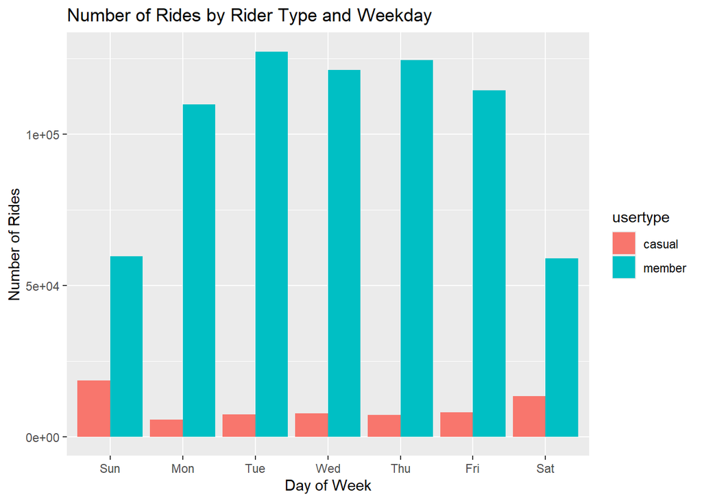

```r
all_bike_trips %>%
  mutate(weekday = wday(started_at, label = TRUE)) %>%
  group_by(usertype, weekday) %>%
  summarise(number_of_rides = n()) %>%
  ggplot(aes(x = weekday, y = number_of_rides, fill = usertype)) +
  geom_col(position = "dodge") +
  labs(title = "Number of Rides by Rider Type and Weekday",
       x = "Day of Week", y = "Number of Rides")
```

# Average ride duration by usertype and weekday

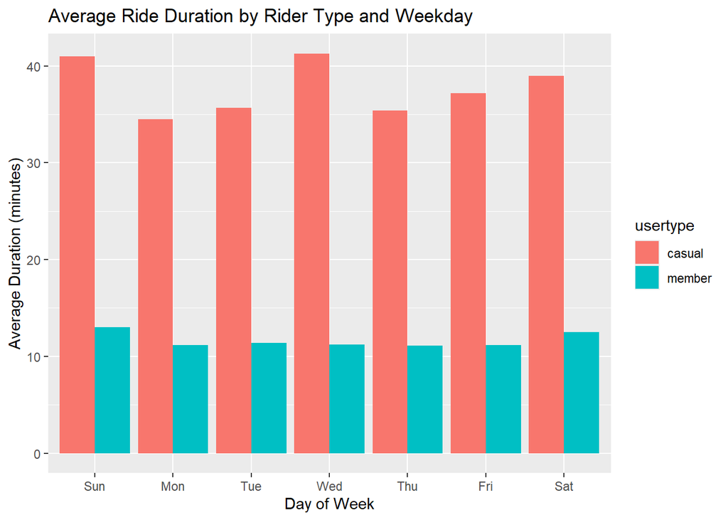

```r
all_bike_trips %>%
  mutate(weekday = wday(started_at, label = TRUE)) %>%
  group_by(usertype, weekday) %>%
  summarise(average_duration = mean(ride_length, na.rm = TRUE)) %>%
  ggplot(aes(x = weekday, y = average_duration, fill = usertype)) +
  geom_col(position = "dodge") +
  labs(title = "Average Ride Duration by Rider Type and Weekday",
       x = "Day of Week", y = "Average Duration (minutes)")
```

# Conclusion and Recommendations

- **Introduce weekend passes for casual riders**: Data shows casual usage is highest on weekends, suggesting strong demand for flexible short-term products.
- **Offer tailored membership plans**: Since many casual riders may be tourists or infrequent users, consider short-term membership variations (e.g., 1-week or monthly passes) as a bridge to annual membership.
- **Promote weekday incentives**: Encourage casual riders to use bikes during weekdays with discounts or promotional campaigns that highlight the convenience of membership for daily travel.

## Data Governance

- Data used in this analysis comes from Divvy’s publicly available datasets.
- All personally identifiable information (PII) has been removed prior to analysis.
- Findings are based on aggregated trends, ensuring ethical and responsible use of the data.